# R Code for Chapter 8 of Introduction to Data Mining: Clustering

# External Cluster Validation

External cluster validation uses ground truth information. That is, the user has an idea how the data should be grouped. This could be a know class label not provided to the clustering algorithm.

We use an artificial data set with known groups here. First, we need to cluster the new data. We do k-means and hierarchical clustering.

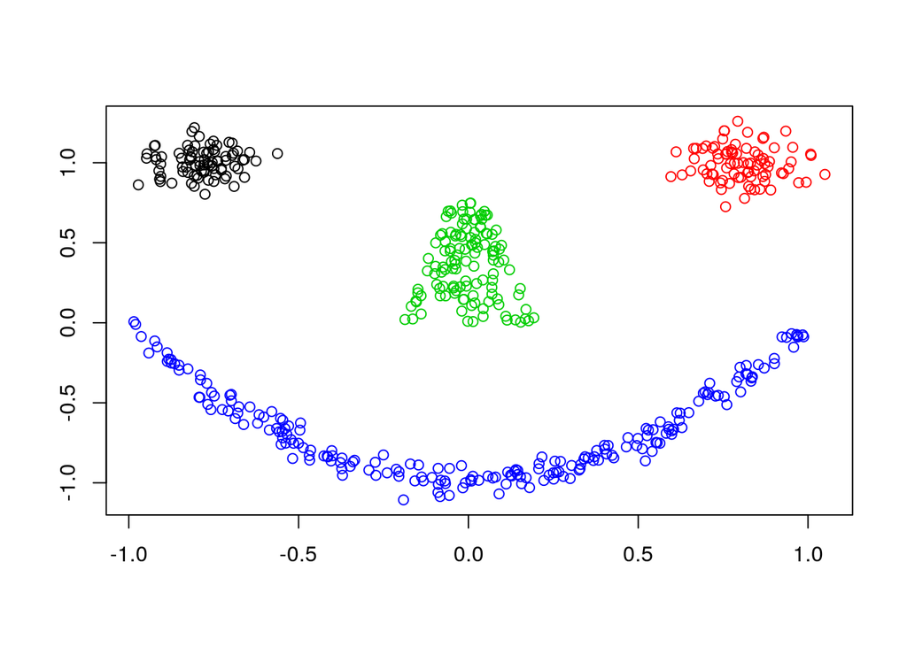

```r
library(mlbench)
shapes <- mlbench.smiley(n=500, sd1 = 0.1, sd2 = 0.05)
plot(shapes)
```

Prepare data

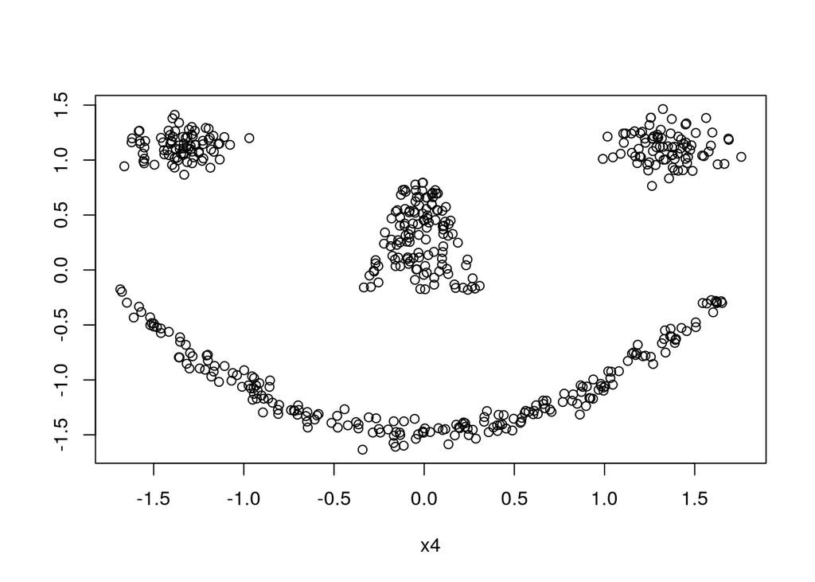

```r
truth <- as.integer(shapes$class)
shapes <- scale(shapes$x)

plot(shapes)
```

Find optimal number of Clusters for k-means

```r
ks <- 2:20
```

Use within sum of squares (look for the knee)

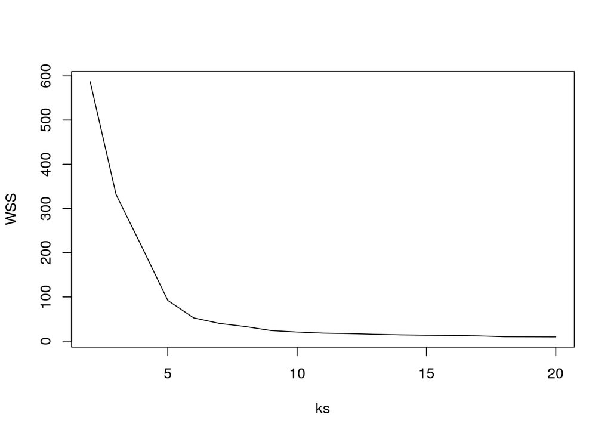

```r
WSS <- sapply(ks, FUN=function(k) {
  kmeans(shapes, centers=k, nstart=10)$tot.withinss
})
plot(ks, WSS, type="l")
```

looks like 6 clusters

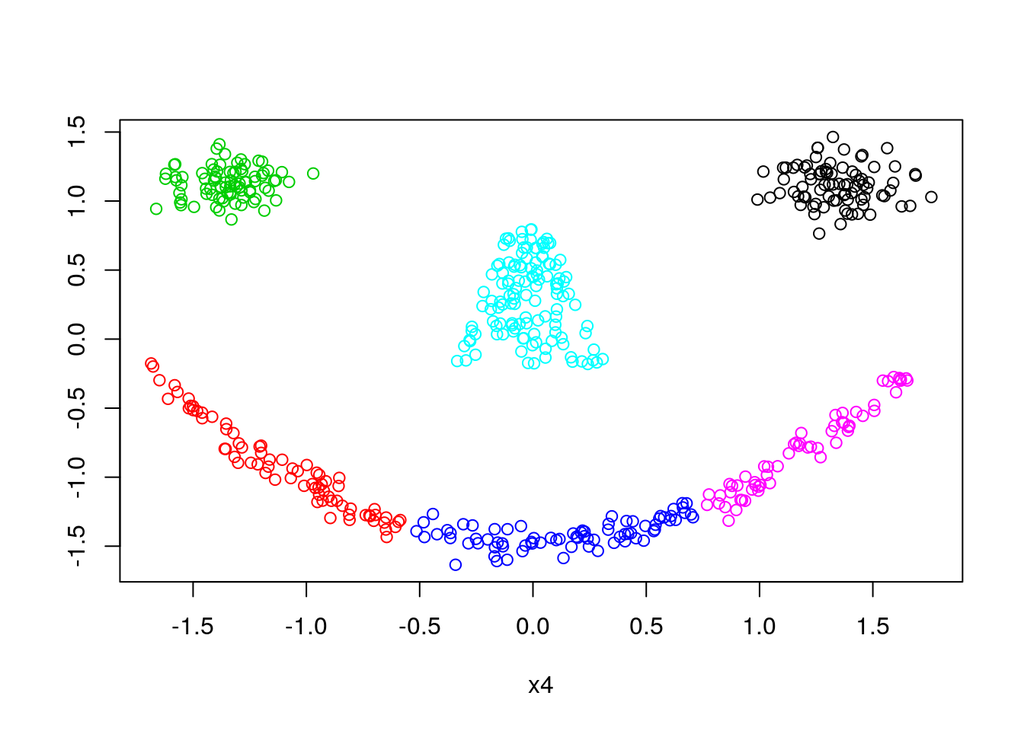

```r
km <- kmeans(shapes, centers=6, nstart = 10)
plot(shapes, col=km$cluster)
```

Hierarchical clustering: single-link because of the mouth

```r
d <- dist(shapes)
hc <- hclust(d, method="single")
```

Find optimal number of clusters

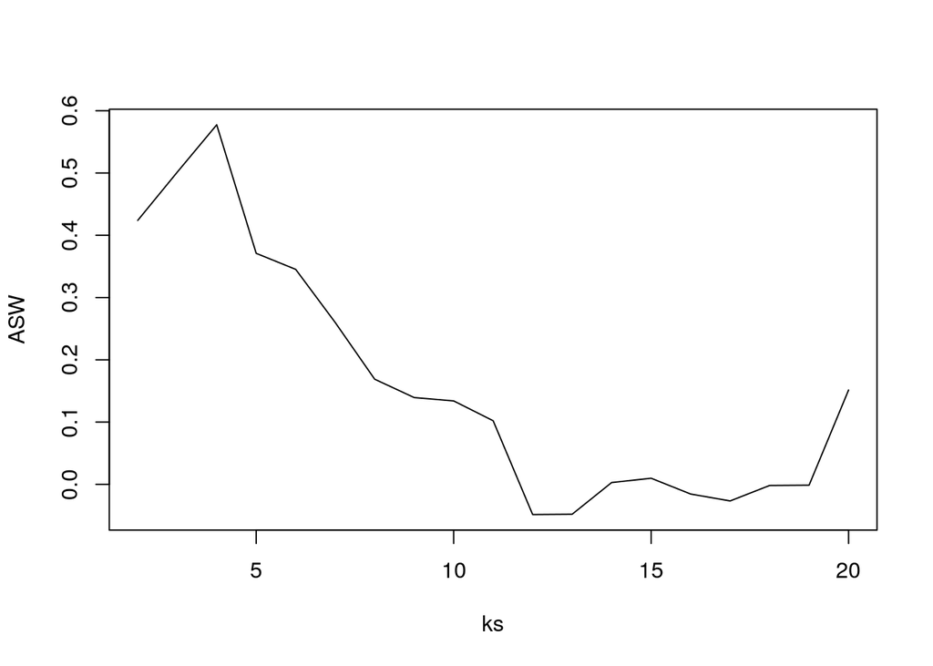

```r
ASW <- sapply(ks, FUN=function(k) {
  fpc::cluster.stats(d, cutree(hc, k))$avg.silwidth
})
plot(ks, ASW, type="l")
```

4 clusters

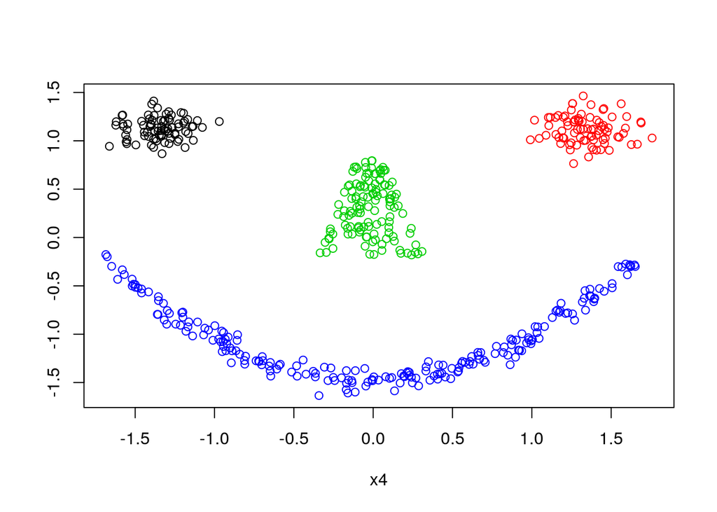

```r
hc_4 <- cutree(hc, 4)
plot(shapes, col=hc_4)
```

Spectral Clustering

```r
spec <- specc(shapes, centers = 4)
```

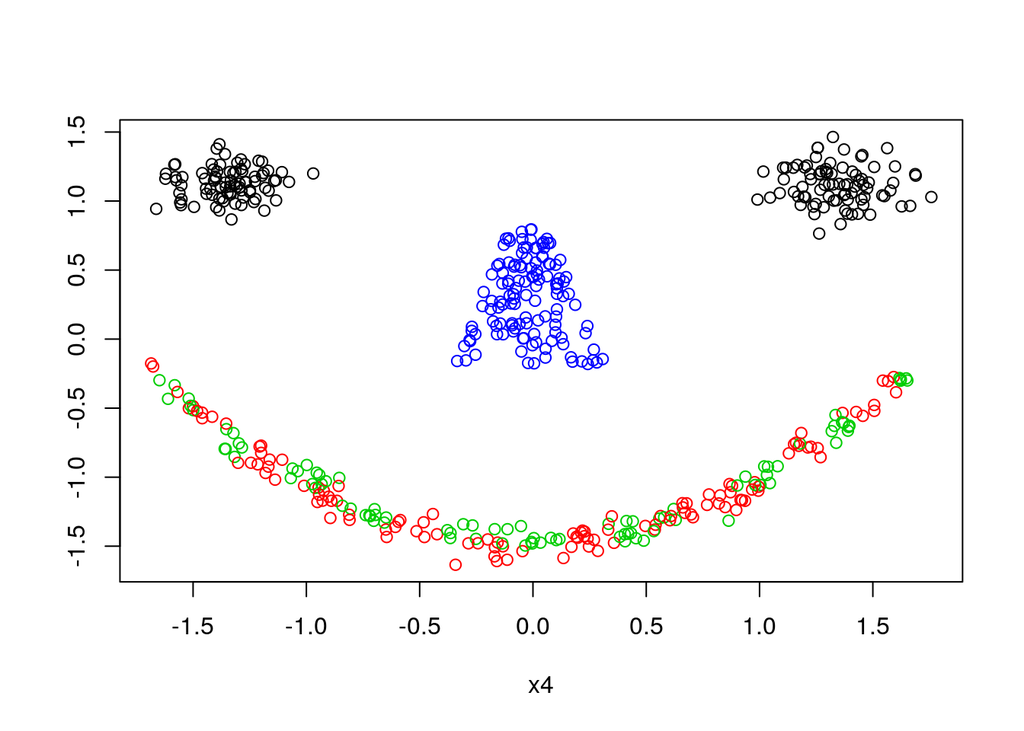

```r
plot(shapes, col=spec)
```

Compare with ground truth with the corrected (=adjusted) Rand index (ARI), the variation of information (VI) index, entropy and purity.

```r
#
```

define entropy and purity

```r
entropy <- function(cluster, truth) {
  k <- max(cluster, truth)
  cluster <- factor(cluster, levels = 1:k)
  truth <- factor(truth, levels = 1:k)
  m <- length(cluster)
  mi <- table(cluster)

  cnts <- split(truth, cluster)
  cnts <- sapply(cnts, FUN = function(n) table(n))
  p <- sweep(cnts, 1, rowSums(cnts), "/")
  p[is.nan(p)] <- 0
  e <- -p * log(p, 2)
  sum(rowSums(e, na.rm = TRUE) * mi/m)
}

purity <- function(cluster, truth) {
  k <- max(cluster, truth)
  cluster <- factor(cluster, levels = 1:k)
  truth <- factor(truth, levels = 1:k)
  m <- length(cluster)
  mi <- table(cluster)

  cnts <- split(truth, cluster)
  cnts <- sapply(cnts, FUN = function(n) table(n))
  p <- sweep(cnts, 1, rowSums(cnts), "/")
  p[is.nan(p)] <- 0

  sum(apply(p, 1, max) * mi/m)
}
```

calculate measures (for comparison we also use random “clusterings” with 4 and 6 clusters)

```r
random4 <- sample(1:4, nrow(shapes), replace = TRUE)
random6 <- sample(1:6, nrow(shapes), replace = TRUE)

r <- rbind(
  kmeans = c(
    unlist(fpc::cluster.stats(d, km$cluster, truth, compareonly = TRUE)),
    entropy = entropy(km$cluster, truth),
    purity = purity(km$cluster, truth)
    ),
  hc = c(
    unlist(fpc::cluster.stats(d, hc_4, truth, compareonly = TRUE)),
    entropy = entropy(hc_4, truth),
    purity = purity(hc_4, truth)
    ),
  spec = c(
    unlist(fpc::cluster.stats(d, spec, truth, compareonly = TRUE)),
    entropy = entropy(spec, truth),
    purity = purity(spec, truth)
    ),
  random4 = c(
    unlist(fpc::cluster.stats(d, random4, truth, compareonly = TRUE)),
    entropy = entropy(random4, truth),
    purity = purity(random4, truth)
    ),
  random6 = c(
    unlist(fpc::cluster.stats(d, random6, truth, compareonly = TRUE)),
    entropy = entropy(random6, truth),
    purity = purity(random6, truth)
    )
  )
r
```

```
##         corrected.rand        vi   entropy    purity
## kmeans    0.6813731586 0.4565932 0.2426881 0.5347368
## hc        1.0000000000 0.0000000 0.0000000 1.0000000
## spec      0.6458608178 0.5168628 0.2474135 0.8899522
## random4   0.0006816852 2.6648245 1.9721384 0.2902777
## random6  -0.0032093133 3.0796690 1.6982724 0.1356814
```

Hierarchical clustering found the perfect clustering.

Read `? cluster.stats` for an explanation of all the available indices.

# Related Topics

## Outlier Removal

It is often useful to remove outliers prior to clustering. A density based method to identify outlier is LOF (Local Outlier Factor). It is related to dbscan and compares the density around a point with the densities around its neighbors. The LOF value for a regular data point is 1. The larger the LOF value gets, the more likely the point is and outlier.

```r
library(dbscan)
lof <- lof(ruspini_scaled, k = 3)
lof
```

```
##  [1] 0.9877325 1.0628597 1.0317734 0.9474550 1.0261991 0.9685075 0.9949537
##  [8] 1.1662336 1.2548148 1.1522791 0.9050859 1.1090965 0.9600630 1.0468833
## [15] 1.3493687 1.0684332 1.5797927 1.0369170 1.0252235 1.3051998 1.0865717
## [22] 0.9361902 1.0662241 1.0534516 1.0476252 1.4061012 1.0404476 0.9852975
## [29] 1.0570035 0.9373427 1.2592287 2.5742150 1.0262933 1.0028878 1.0621644
## [36] 1.5655033 1.0684003 0.9454461 0.9536000 0.9316231 1.0362371 1.1050229
## [43] 1.0935726 0.9003925 1.0887629 1.7126320 0.9280241 1.0549747 1.2076553
## [50] 1.0945647 1.1418777 1.7358598 1.0166549 1.2551881 0.9776748 0.9962944
## [57] 1.0865580 0.9455904 1.0404476 0.9845147 1.1179754 1.0177615 1.1087293
## [64] 1.0843475 0.9209500 1.2942336 0.9984568 1.2593935 1.0684003 1.8228159
## [71] 0.9997776 1.0442617 1.1365860 1.1089301 0.7880617
```

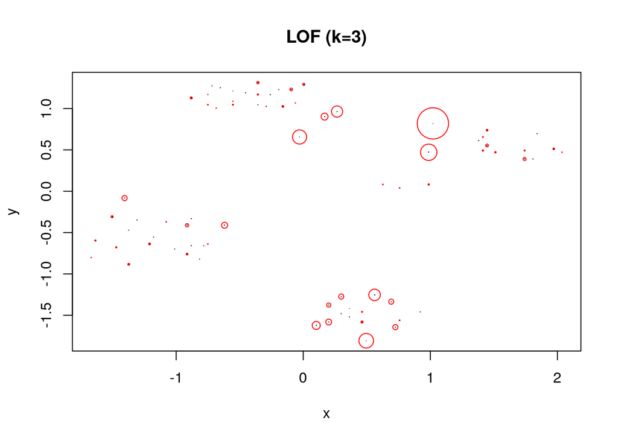

```r
plot(ruspini_scaled, pch = ".", main = "LOF (k=3)")
points(ruspini_scaled, cex = (lof-1)*3, pch = 1, col="red")
```

Find outliers (find the knee)

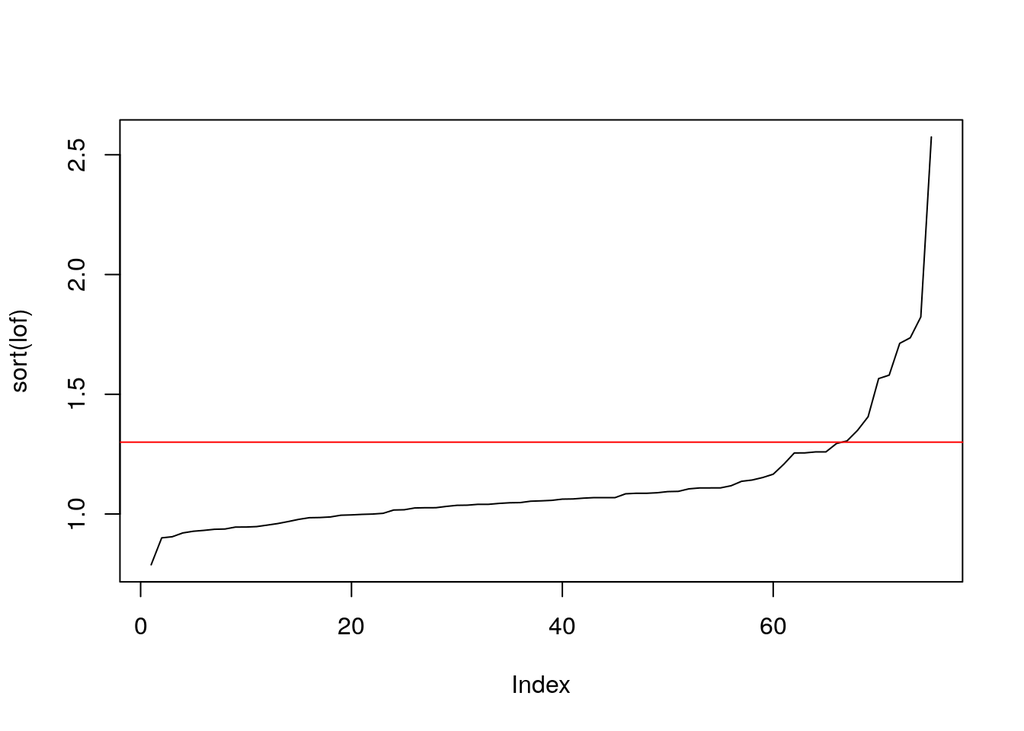

```r
plot(sort(lof), type = "l")
abline(h = 1.3, col = "red")
```

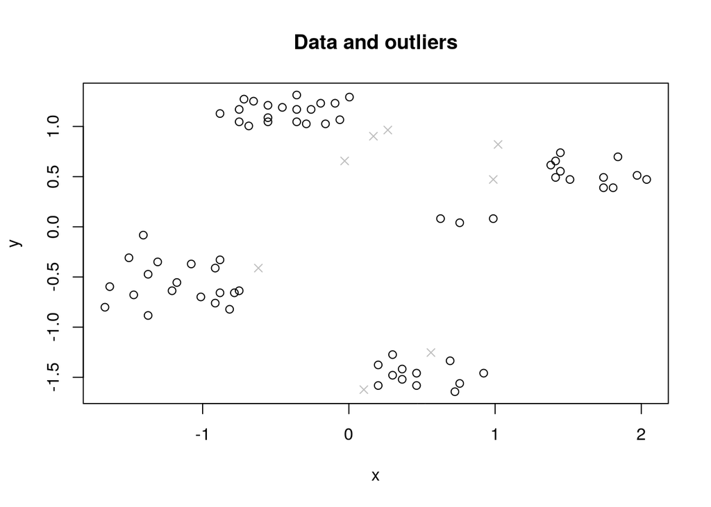

```r
plot(ruspini_scaled[lof < 1.3,], main = "Data and outliers")
points(ruspini_scaled[lof >= 1.3,], col = "grey", pch = 4)
```

There are many other outlier removal strategies available. See, e.g., package outliers.

## Clustering Tendency

Most clustering algorithms will always produce a clustering, even if the data does not contain a cluster structure. It is typically good to check cluster tendency before attempting to cluster the data.

We use again the smiley data.

```r
d_shapes <- dist(shapes)

library(seriation)
```

Visual Analysis for Cluster Tendency Assessment (VAT) reorders the objects to show potential clustering tendency as a block structure (dark blocks along the main diagonal).

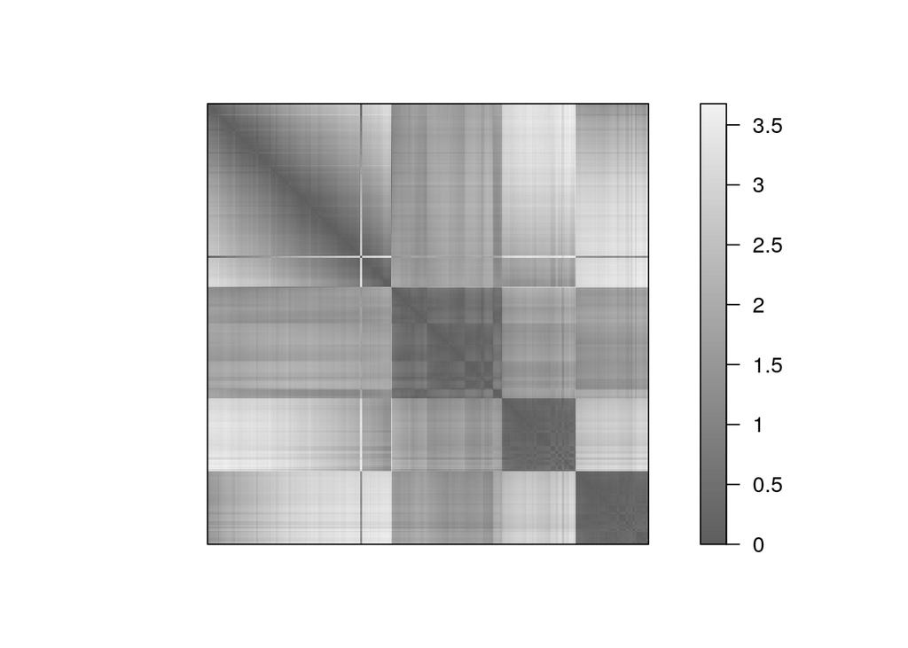

```r
VAT(d_shapes)
```

iVAT uses largest distances in all possible paths between the objects instead of the distances to make the block structure better visible.

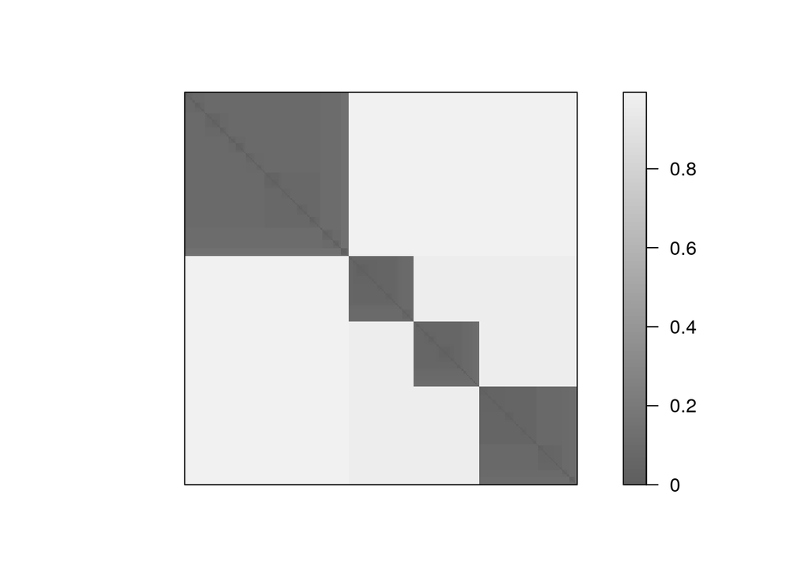

```r
iVAT(d_shapes)
```

Both plots show a strong cluster structure with 4 clusters.

Compare with random data.

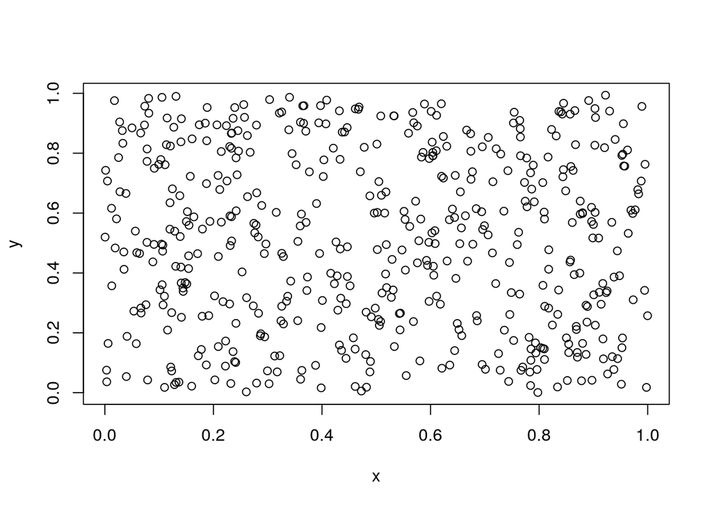

```r
data_random <- matrix(runif(2*500), ncol=2, dimnames = list(NULL, c("x", "y")))
plot(data_random)
```

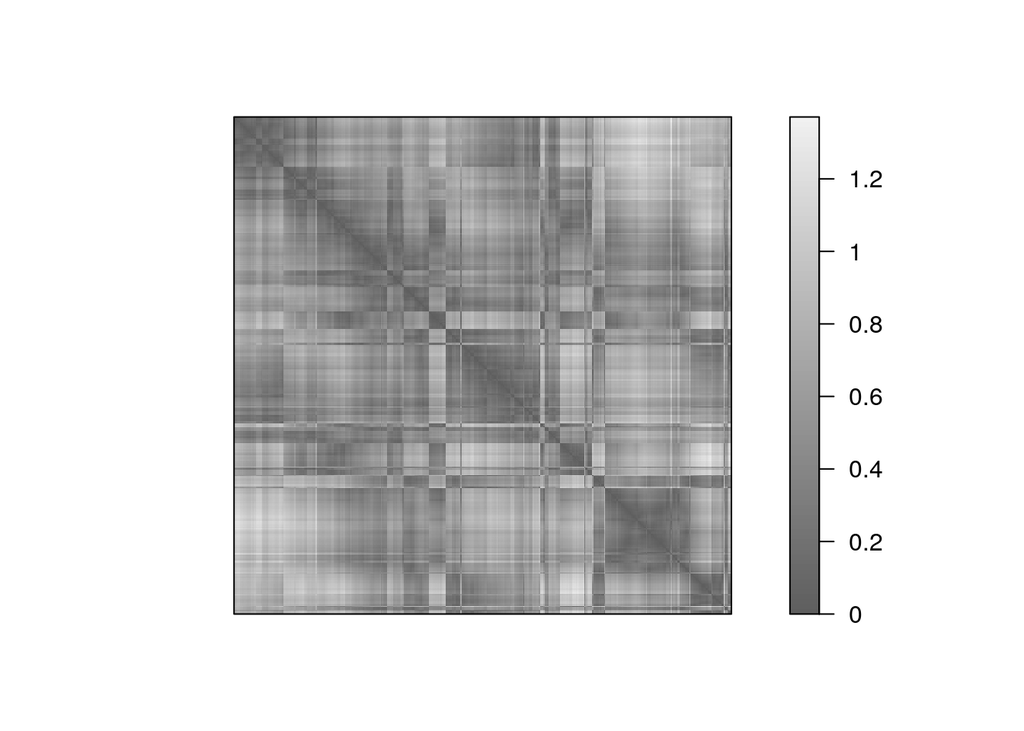

```r
d_random <- dist(data_random)
VAT(d_random)
```

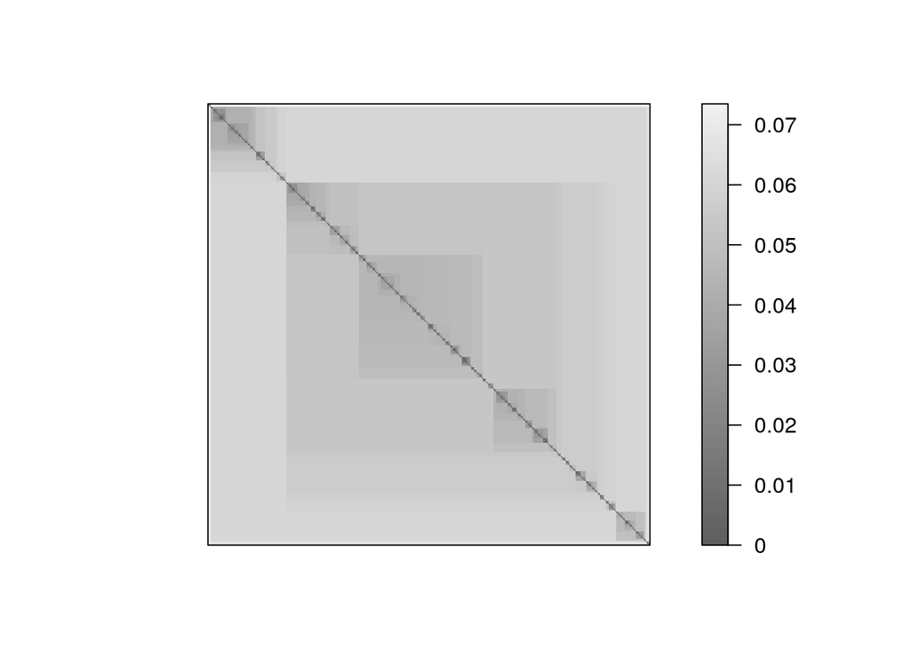

```r
iVAT(d_random)
```

There is very little structure visible.